# Business Understanding

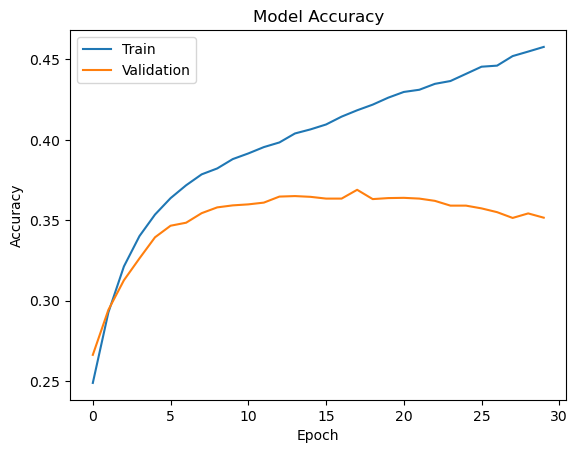

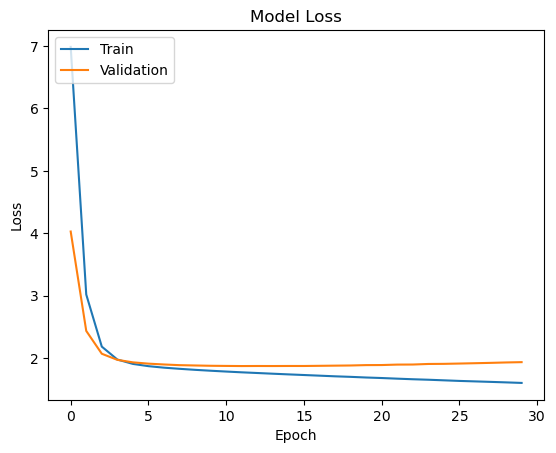

```
              precision    recall  f1-score   support

           0       0.00      0.00      0.00        22
           1       0.00      0.00      0.00        36
           2       0.00      0.00      0.00       165
           3       0.00      0.00      0.00       152
           4       0.36      0.01      0.03       355
           5       0.44      0.09      0.15      1042
           6       0.35      0.08      0.13       265
           7       0.54      0.23      0.32       768
           8       0.49      0.22      0.31      1728
           9       0.00      0.00      0.00       305
          10       0.44      0.11      0.18      1033
          11       0.00      0.00      0.00       437
          12       0.43      0.15      0.23      1692

   micro avg       0.47      0.13      0.21      8000
   macro avg       0.23      0.07      0.10      8000
weighted avg       0.39      0.13      0.19      8000
 samples avg       0.13      0.13      0.13      8000
```

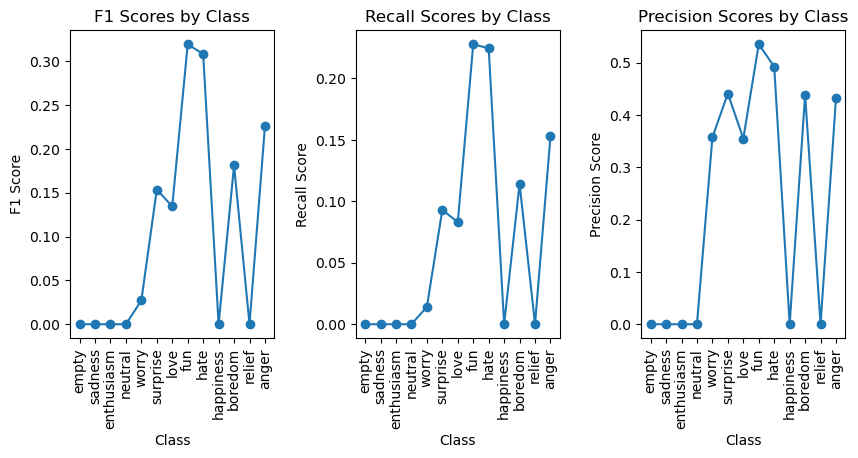

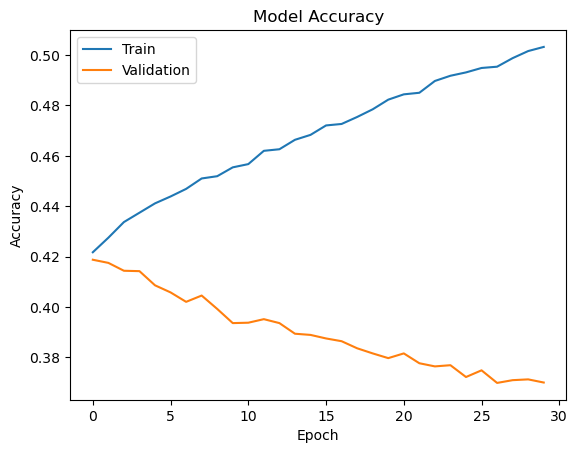

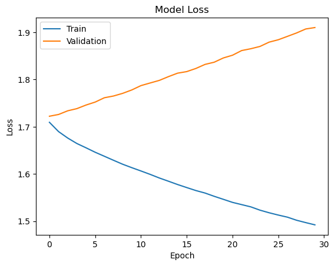

```
              precision    recall  f1-score   support

           0       0.00      0.00      0.00        22
           1       0.00      0.00      0.00        36
           2       0.00      0.00      0.00       165
           3       0.00      0.00      0.00       152
           4       0.23      0.02      0.04       355
           5       0.44      0.16      0.24      1042
           6       0.47      0.12      0.19       265
           7       0.59      0.27      0.37       768
           8       0.49      0.25      0.33      1728
           9       0.14      0.00      0.01       305
          10       0.42      0.15      0.22      1033
          11       0.19      0.01      0.01       437
          12       0.47      0.23      0.31      1692

   micro avg       0.48      0.17      0.26      8000
   macro avg       0.26      0.09      0.13      8000
weighted avg       0.42      0.17      0.24      8000
 samples avg       0.17      0.17      0.17      8000
```

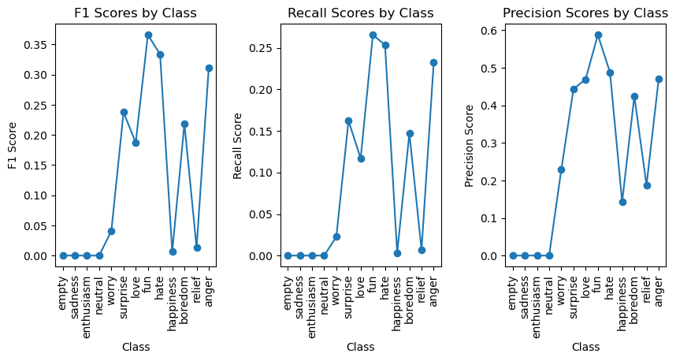

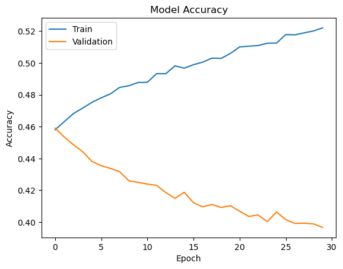

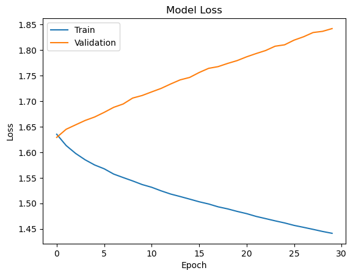

```
              precision    recall  f1-score   support

           0       0.00      0.00      0.00        22
           1       0.00      0.00      0.00        36
           2       0.25      0.01      0.01       165
           3       0.00      0.00      0.00       152
           4       0.21      0.02      0.03       355
           5       0.46      0.20      0.28      1042
           6       0.45      0.17      0.25       265
           7       0.61      0.33      0.43       768
           8       0.53      0.31      0.39      1728
           9       0.33      0.03      0.05       305
          10       0.47      0.19      0.27      1033
          11       0.40      0.03      0.06       437
          12       0.49      0.24      0.32      1692

   micro avg       0.50      0.21      0.30      8000
   macro avg       0.32      0.12      0.16      8000
weighted avg       0.46      0.21      0.28      8000
 samples avg       0.21      0.21      0.21      8000
```

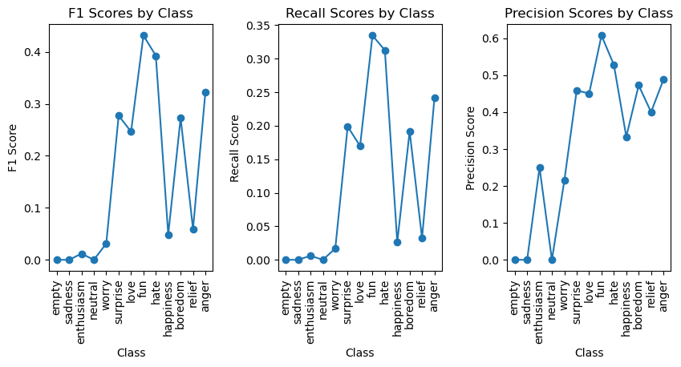

```python
# GRU RNN
model_gru = Sequential()
model_gru.add(Embedding(num_vocab, 300, weights=[embedding_matrix_glove], input_length=300, trainable=False))
model_gru.add(Bidirectional(CuDNNGRU(32, recurrent_regularizer=regularizers.l2(0.15))))
model_gru.add(Dense(13, activation="softmax"))
model_gru.compile(optimizer="adam", loss="categorical_crossentropy", metrics=["accuracy"])


# Default padding is to the longest sequence
for train_index, test_index in sss.split(sequences, target):
    X_train, X_test = final_seqs[train_index], final_seqs[test_index]
    y_train, y_test = target[train_index], target[test_index]

    hist = model_gru.fit(X_train, y_train, epochs=30, batch_size=256, validation_split=0.2)
    y_pred = np.rint(model_gru.predict(X_test))
    plot_history(hist)
    print(classification_report(y_test, y_pred, zero_division=0))
    plot_metrics(classification_report(y_test, y_pred, zero_division=0, output_dict=True))
```

# Hyperparameter Tuning Details & Experimentation

For the hyperparameters, the ones we modified were the embedding size, regularization term, and the number of units in the RNN. We also removed a Dense layer from the inital models, in both the GRU and the LSTM. The number of units was modified because the RNN frequently ran into issues with overfitting, as the accuracy tended to be higher but the validation was getting lower. To combat this, we decreased the number of units so that the loss of the validation set is proportional to the loss of the training set. By default, it was set to 64 but then we modified to 32; we did this because 64 was a middlepoint between the size of the input and the size of our output. We decrease it by 1 power of 2 to decrease the amount of overfitting; the smaller the unit size the less likely we are to overfit. This made our loss more porportional with respect to training and validation. The loss was still going up over time, so to combat this so we added L2 regularization to several of the models. This generalizes our predictions more, and reduces bias on any given node and reduces overfitting to our training set. For embedding sizes, we determined it by the number of vocabulary terms (word_index + 1; the length of the word_index of the tokenizer plus 1) and the size of any given vocabulary term within our word embeddings (300 dimensions per vector) for Glove and Numberbatch.

# Multi-chain

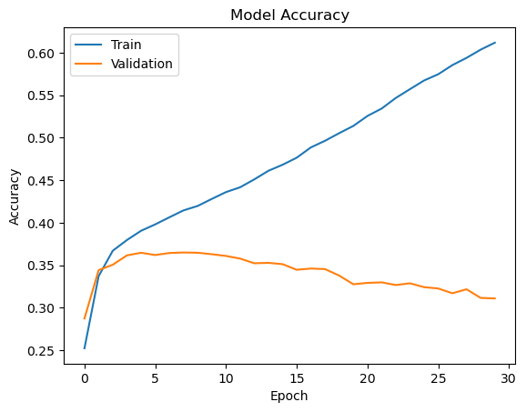

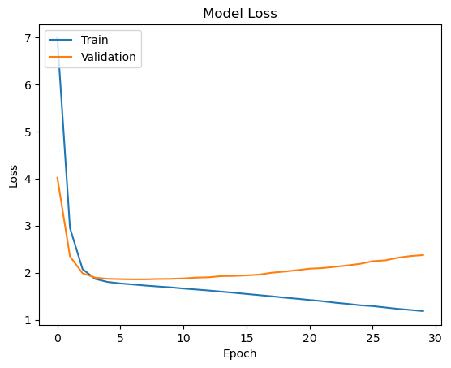

```
              precision    recall  f1-score   support

           0       0.00      0.00      0.00        22
           1       0.00      0.00      0.00        36
           2       0.00      0.00      0.00       165
           3       0.00      0.00      0.00       152
           4       0.23      0.03      0.05       355
           5       0.40      0.21      0.27      1042
           6       0.27      0.17      0.21       265
           7       0.44      0.32      0.37       768
           8       0.39      0.28      0.32      1728
           9       0.09      0.02      0.03       305
          10       0.32      0.19      0.24      1033
          11       0.13      0.02      0.04       437
          12       0.38      0.28      0.32      1692

   micro avg       0.37      0.21      0.27      8000
   macro avg       0.20      0.12      0.14      8000
weighted avg       0.33      0.21      0.25      8000
 samples avg       0.21      0.21      0.21      8000
```

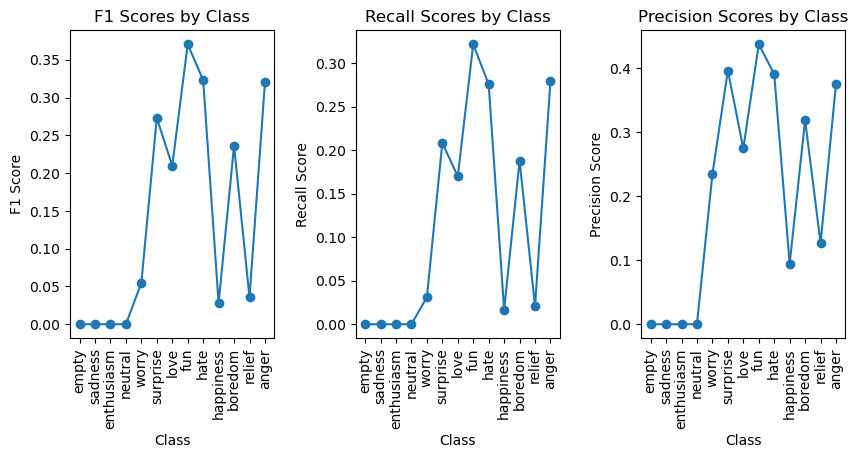

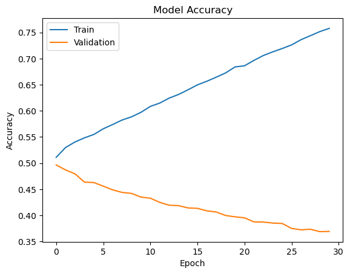

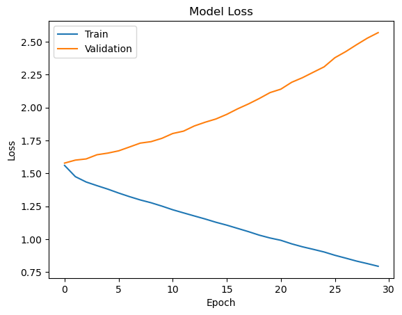

```
              precision    recall  f1-score   support

           0       0.00      0.00      0.00        22
           1       0.00      0.00      0.00        36
           2       0.17      0.02      0.03       165
           3       0.00      0.00      0.00       152
           4       0.21      0.10      0.13       355
           5       0.41      0.32      0.36      1042
           6       0.36      0.23      0.28       265
           7       0.46      0.38      0.42       768
           8       0.44      0.42      0.43      1728
           9       0.17      0.06      0.09       305
          10       0.37      0.38      0.38      1033
          11       0.22      0.08      0.11       437
          12       0.43      0.32      0.37      1692

   micro avg       0.41      0.30      0.35      8000
   macro avg       0.25      0.18      0.20      8000
weighted avg       0.38      0.30      0.33      8000
 samples avg       0.30      0.30      0.30      8000
```

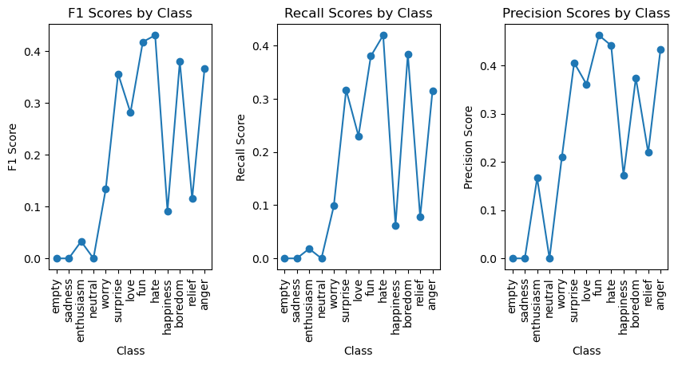

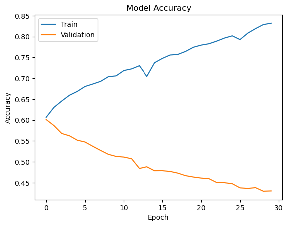

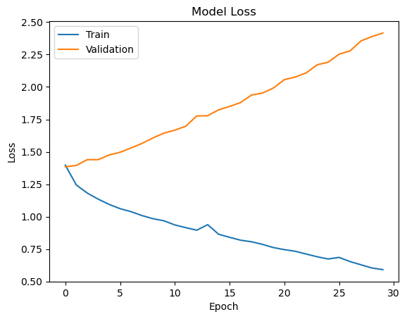

```
              precision    recall  f1-score   support

           0       0.00      0.00      0.00        22
           1       0.25      0.03      0.05        36
           2       0.12      0.02      0.04       165
           3       0.35      0.05      0.09       152
           4       0.29      0.15      0.20       355
           5       0.47      0.38      0.42      1042
           6       0.43      0.32      0.37       265
           7       0.54      0.43      0.48       768
           8       0.49      0.48      0.48      1728
           9       0.36      0.16      0.22       305
          10       0.45      0.42      0.43      1033
          11       0.24      0.14      0.17       437
          12       0.49      0.45      0.47      1692

   micro avg       0.46      0.38      0.41      8000
   macro avg       0.34      0.23      0.26      8000
weighted avg       0.44      0.38      0.40      8000
 samples avg       0.38      0.38      0.38      8000
```

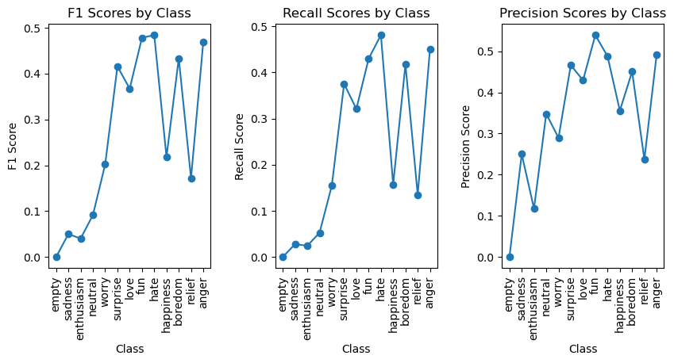

```python
# GRU RNN
model_multichain_gru = Sequential()
model_multichain_gru.add(Embedding(num_vocab, 300, weights=[embedding_matrix_glove], input_length=300, trainable=False))
model_multichain_gru.add(Bidirectional(CuDNNGRU(32, return_sequences=True)))
model_multichain_gru.add(Bidirectional(CuDNNGRU(32, recurrent_regularizer=regularizers.l2(0.15))))
model_multichain_gru.add(Dense(13, activation="softmax"))
model_multichain_gru.compile(optimizer="adam", loss="categorical_crossentropy", metrics=["accuracy"])


# Default padding is to the longest sequence
for train_index, test_index in sss.split(sequences, target):
    X_train, X_test = final_seqs[train_index], final_seqs[test_index]
    y_train, y_test = target[train_index], target[test_index]

    hist = model_multichain_gru.fit(X_train, y_train, epochs=30, batch_size=256, validation_split=0.2)
    y_pred = np.rint(model_multichain_gru.predict(X_test))
    plot_history(hist)
    print(classification_report(y_test, y_pred, zero_division=0))
    plot_metrics(classification_report(y_test, y_pred, zero_division=0, output_dict=True))
```

# Model Comparison & Secondary Hyperparameter explanation

In the base models for the LSTM and GNU, we saw that the LSTM had the highest overall F1 score & recall (the macro average F1 Score in stated in the classification report printout). Although each of the networks didn't achieve the accuracy we desired due to constraints on epochs as they were very time intensive operations for our machines, we tuned our hyper parameters to optimize the results to minimize loss, and improve validation accuracy.

In the plots for calculating each of the evaluation metrics scores per class label, we observed that sadness, neutral, and enthusiasm scored much low on the hyper parameter tuned models than the base models with significant differences. In the base models, the metrics were measured a little above .1 across those three classes but in the tuned models they were around 0. In general we observed that some of the models had a large discrepancies between precision and recall scores per class. For example, the tuned Bi LSTM model had a Recall score around .15 for happiness but the Precision score was much higher around .35. This means that the model was good at classifying the actual result of the sample than overall positive classification.

This would ideal for us because given the business context, it is important to correctly classify sentiment per tweet as this data could be fed into systems which rely on an identification of social sentiment, or the results could be used for understanding users sentiment towards a specific event. However, this only applies if uniformity of a higher precision score was applied across all classes.

# Numberbatch

```python
# Load in the word embeddings
word_vectors = {}
for line in open("numberbatch-en.txt"):
    value = line.split(' ')
    word_vectors[value[0]] = np.array(value[1:],dtype = 'float32')

# Apply embeddings to dataset
embedding_matrix_numberbatch = np.zeros((num_vocab, 300))
for word, index in tokenizer.word_index.items():
    embedding = word_vectors.get(word)
    if embedding is not None:
        embedding_matrix_numberbatch[index] = embedding
```

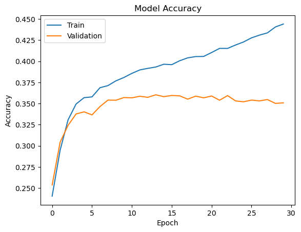

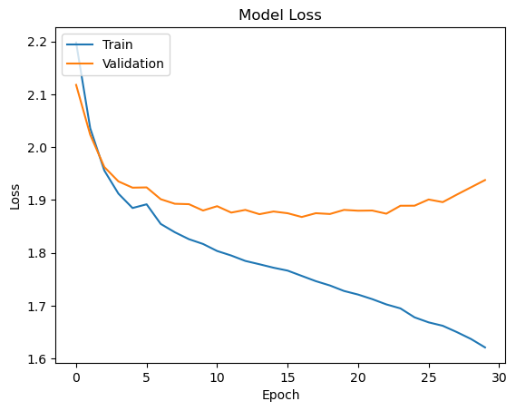

```
              precision    recall  f1-score   support

           0       0.00      0.00      0.00        22
           1       0.00      0.00      0.00        36
           2       0.00      0.00      0.00       165
           3       0.00      0.00      0.00       152
           4       0.00      0.00      0.00       355
           5       0.50      0.12      0.19      1042
           6       0.39      0.14      0.20       265
           7       0.54      0.28      0.37       768
           8       0.49      0.23      0.31      1728
           9       0.00      0.00      0.00       305
          10       0.43      0.13      0.20      1033
          11       0.00      0.00      0.00       437
          12       0.49      0.17      0.26      1692

   micro avg       0.49      0.15      0.23      8000
   macro avg       0.22      0.08      0.12      8000
weighted avg       0.39      0.15      0.21      8000
 samples avg       0.15      0.15      0.15      8000
```

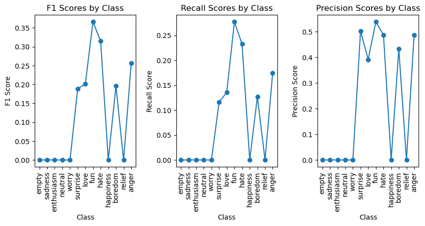

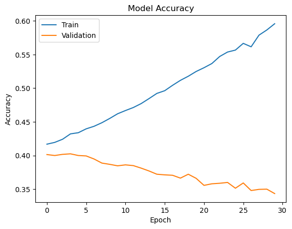

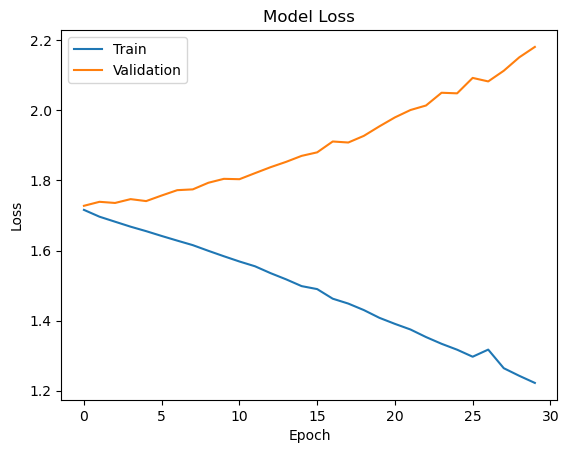

```
              precision    recall  f1-score   support

           0       0.00      0.00      0.00        22
           1       0.00      0.00      0.00        36
           2       0.00      0.00      0.00       165
           3       0.00      0.00      0.00       152
           4       0.18      0.05      0.08       355
           5       0.42      0.20      0.27      1042
           6       0.35      0.21      0.26       265
           7       0.53      0.29      0.38       768
           8       0.45      0.32      0.37      1728
           9       0.19      0.03      0.05       305
          10       0.41      0.23      0.30      1033
          11       0.23      0.03      0.06       437
          12       0.42      0.26      0.32      1692

   micro avg       0.43      0.22      0.29      8000
   macro avg       0.24      0.12      0.16      8000
weighted avg       0.39      0.22      0.28      8000
 samples avg       0.22      0.22      0.22      8000
```

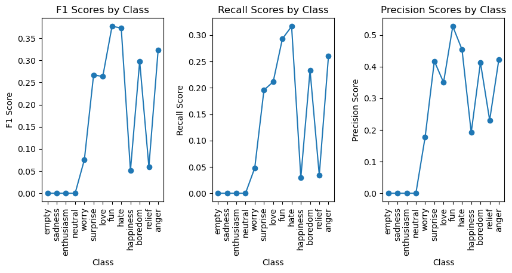

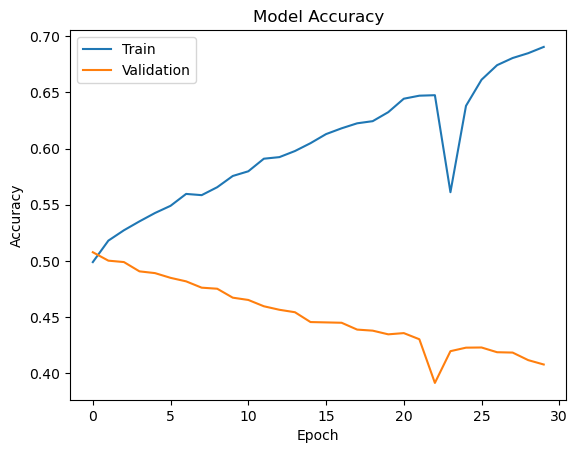

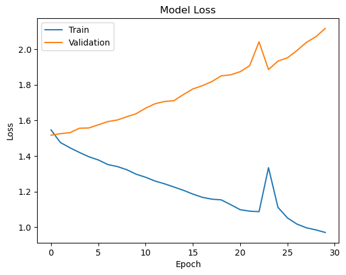

```
              precision    recall  f1-score   support

           0       0.00      0.00      0.00        22
           1       0.00      0.00      0.00        36
           2       0.00      0.00      0.00       165
           3       0.00      0.00      0.00       152
           4       0.21      0.10      0.14       355
           5       0.46      0.33      0.39      1042
           6       0.43      0.25      0.32       265
           7       0.55      0.39      0.46       768
           8       0.51      0.38      0.44      1728
           9       0.38      0.13      0.19       305
          10       0.45      0.31      0.37      1033
          11       0.26      0.11      0.16       437
          12       0.49      0.39      0.43      1692

   micro avg       0.47      0.31      0.37      8000
   macro avg       0.29      0.18      0.22      8000
weighted avg       0.44      0.31      0.36      8000
 samples avg       0.31      0.31      0.31      8000
```

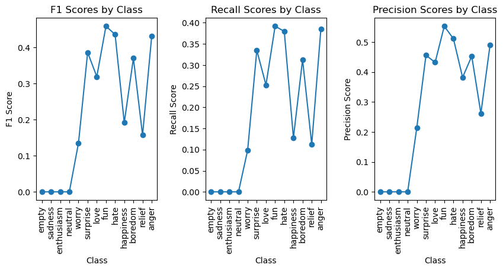

```python
# LSTM RNN
model_bi_lstm = Sequential()
model_bi_lstm.add(Embedding(num_vocab, 300, weights=[embedding_matrix_numberbatch], input_length=300, trainable=False))
model_bi_lstm.add(Bidirectional(CuDNNLSTM(75)))
model_bi_lstm.add(Dense(32, activation="relu"))
model_bi_lstm.add(Dense(13, activation="softmax"))
model_bi_lstm.compile(optimizer="adam", loss="categorical_crossentropy", metrics=["accuracy"])


# Default padding is to the longest sequence
for train_index, test_index in sss.split(sequences, target):
    X_train, X_test = final_seqs[train_index], final_seqs[test_index]
    y_train, y_test = target[train_index], target[test_index]

    hist = model_bi_lstm.fit(X_train, y_train, epochs=30, batch_size=256, validation_split=0.2)
    y_pred = np.rint(model_bi_lstm.predict(X_test))
    plot_history(hist)
    print(classification_report(y_test, y_pred, zero_division=0))
    plot_metrics(classification_report(y_test, y_pred, zero_division=0, output_dict=True))
```

# Numberbatch Reasoning

Because we are doing NLP, taking in some text data and trying to classify to some sentiment; we must be able to accurately guage the semantics of any given word. We can do this with predefined word embeddings. Numberbatch ends up being a more compatible word embedding because the embedding are hand tuned by researchers to reduce the emotional bias present from the general public. Because these large word embeddings are typically sourced by crawling the web, or from biased sources, they tend to pickup common connotations of words. For instance, names; something like John could pickup a positive sentiment than another name, which may not make much sense. Number batch is useful for us because researchers reduce bias within the embeddings, which we want because we want an accurate depiction about the emotion presented by the tweet writer in the tweet. Numberbatch is effectively denoised from any bias.